# Metric and Categorical

## Research question

We want to know whether there is a difference between males and females with respect to our most important variable: the aspiration for career success. To that end, we formulate the following hypotheses to perform a statistical test using a significance level $\alpha=0.05$:

- $H_0: \mu^{Erfolg}_{male} = \mu^{Erfolg}_{female}$
- $H_A: \mu^{Erfolg}_{male} \neq \mu^{Erfolg}_{female}$

```r
library(psych)
data <- read.csv('survey_696322_R_data_file.csv')
data <- data[,c(3,5)]
indx <- sapply(data, is.factor)
data[indx] <- lapply(data[indx], as.numeric)
pca.result <- principal(data, nfactors = 1, scores = TRUE)
erfolg.scores <- pca.result$scores[,'PC1']
data <- read.csv('survey_696322_R_data_file.csv')
data['erfolg'] <- erfolg.scores
```

After we load our data, we split it along the `Geschlecht` variable.

```r
females <- data[data$Q014 == 1,]
males <- data[data$Q014 == 2,]
summary(females$erfolg)
```

```
##    Min. 1st Qu.  Median    Mean 3rd Qu.    Max.
## -2.1894 -0.4530  0.2352  0.1446  0.7593  1.9716
```

Above, we see a summary statistic of the `Erfolg` variable among females.

```r
summary(males$erfolg)
```

```
##     Min.  1st Qu.   Median     Mean  3rd Qu.     Max.
## -2.18942 -0.97711 -0.09314 -0.08491  0.59510  1.97158
```

If we compare the summary statistics of the `Erfolg` variable among both genders, we see that there is some difference in the means and median. We can also observe the differences in the below plot.

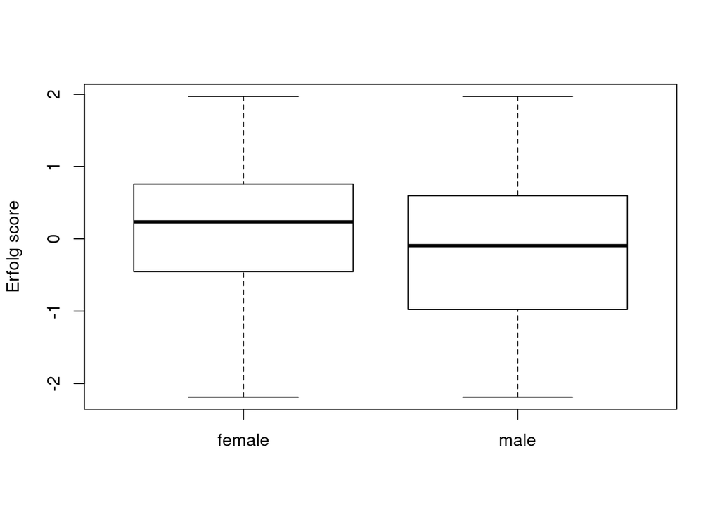

```r
boxplot(list(females$erfolg, males$erfolg), names = c('female', 'male'), ylab = 'Erfolg score')
```

The above plot shows the boxplots of both genders. We see that there exists some difference in both the median and the interquartile distance. We can also see that both boxplots are approximately normally distributed. As the female and male `Erfolg` scores are independent, we will test our prior defined hypotheses using a Two Sample t-test.

## Test

```r
t.test(females$erfolg, males$erfolg)
```

```
##
##  Welch Two Sample t-test
##
## data:  females$erfolg and males$erfolg
## t = 1.131, df = 80.137, p-value = 0.2614
## alternative hypothesis: true difference in means is not equal to 0
## 95 percent confidence interval:
##  -0.1743025  0.6333016
## sample estimates:
##   mean of x   mean of y
##  0.14458473 -0.08491484
```